# Introduction to R Practical session - All chapters in one

MSE Core Module 1.1

Author

Affiliation

Federico Marini

Institute of Medical Biostatistics, Epidemiology and Informatics (IMBEI), Mainz, Germany

Published

October 16, 2026

# 1 Chapter 1

Here you can find the material for the topics addressed in Chapter 1.

## 1.1 Checking R’s documentation

Using `help` / `?`

```r
## this calls the help for a function to plot a histogram
?hist
# this is just the same
help(hist) ## what about ??
```

Check out what these do

```r
?apropos
apropos("row")
```

```
#>  [1] ".row"                   ".rowMeans"              ".rowNamesDF<-"
#>  [4] ".rowSums"               "arrows"                 "browseEnv"
#>  [7] "browser"                "browserCondition"       "browserSetDebug"
#> [10] "browserText"            "browseURL"              "browseVignettes"
#> [13] "n2mfrow"                "nrow"                   "NROW"
#> [16] "PlantGrowth"            "row"                    "row.names"
#> [19] "row.names.data.frame"   "row.names.default"      "row.names<-"
#> [22] "row.names<-.data.frame" "row.names<-.default"    "rowMeans"
#> [25] "rownames"               "rownames<-"             "rowsum"
#> [28] "rowsum.data.frame"      "rowsum.default"         "rowSums"
#> [31] "ToothGrowth"            "xpdrows.data.frame"
```

```r
??row
```

## 1.2 Using comments in a chunk

```r
# This is a comment

## This is also a comment

## Comments can also go
## over multiple lines
##
## and be empty lines (see just above you)
```

# 2 Chapter 2

Here you can find the material for the topics addressed in Chapter 2.

## 2.1 R is a powerful calculator

Type the following

```r
2 + 2
```

```
#> [1] 4
```

```r
log(2)
```

```
#> [1] 0.6931472
```

```r
347 * 73841
```

```
#> [1] 25622827
```

```r
7/2
```

```
#> [1] 3.5
```

```r
7%/%2
```

```
#> [1] 3
```

```r
7%%2
```

```
#> [1] 1
```

```r
6^7
```

```
#> [1] 279936
```

```r
42 * 10^-42
```

```
#> [1] 4.2e-41
```

```r
sqrt(10000)
```

```
#> [1] 100
```

## 2.2 R has a workspace

… and that can contain (any) object.

```r
ls()
```

```
#> character(0)
```

## 2.3 Objects, and assignments

Historically, the underscore was also used for the assignment!

```r
a <- 1
```

These are the same

```r
2+2
```

```
#> [1] 4
```

```r
2 + 2
```

```
#> [1] 4
```

```r
3*(2+1)
```

```
#> [1] 9
```

```r
3 * (2 + 1)
```

```
#> [1] 9
```

```r
a<-"thisthing"
a <- "thisthing"
```

What is better? Why?

Let the code breath, let the reader think of|read|enjoy what you wrote

Hit that Enter key every now and then!

Use the support provided by the IDE for the indentation & co

## 2.4 Errors, warnings, messages

Three type of information coming from the console

**Errors**: Something went wrong, execution stops

**Warnings**: Something does not smell too right, calls for some inspection

**Messages**: Potentially harmless, potentially very useful. Read them

## 2.5 What are packages?

R packages…

- Are fundamental components of R ecosystem
- Extend base R functionality for a specific purpose
- Bundle new functions, data sets, and documentation
- Are contributed by independent developers (it could be you!)
- Have a dependency management to install “everything that is needed”

## 2.6 Where can I find packages?

Repositories:

- CRAN: Managed official package repository network
- Bioconductor: curated bioinformatics packages (vignettes mandatory, integrated ecosystem!)
- GitHub: un-managed, bleeding edge

## 2.7 How to use packages

- **Install**: once (for every major R version)
- **Load**: in each session
- **Use** like any base R functionality, calling the `new_function()` - works also like `pkg::fun()` (it is sometimes good to be explicit)

Relevant commands:

- `install.packages("packagename")` - check it online at CRAN!
- `installed.packages()` (and know what is the `.libPaths()`)
- `update.packages()`
- `library("packagename")`
- `help(package="packagename")`, `data()`, `browseVignettes()`, `vignette()`, `citation("packagename")`

If on Bioconductor: `BiocManager::install()`

# 3 Chapter 3

Here you can find the material for the topics addressed in Chapter 3

## 3.1 Required packages

We are going to need these packages

```r
library("readxl")
library("readr")
library("janitor")
library("dplyr")
library("tidyr")
library("writexl")
library("haven")
library("ggplot2")
library("ggforce")
```

How do we get them installed? (Tip, you can do more than one in a single command!)

```r
install.packages(
  c("readxl",
    "readr",
    "janitor",
    "dplyr",
    "tidyr",
    "writexl",
    "haven",
    "ggplot2",
    "ggforce"))
```

## 3.2 Going by hand

This is possibly a “friends don’t let friends” kind of thing

Still, let’s see where this takes us:

```r
head(penguins_raw)
pen_id <- c(1, 2, 3, 4, 5, 6)
pen_species <- c("Adelie", "Adelie", "Adelie", "Adelie", "Adelie", "Adelie")

diy_penguins <- data.frame(
  id = pen_id,
  species = pen_species
)
cbind(pen_id, pen_species)

pen_species <- rep("Adelie", 6)
diy_penguins <- data.frame(
  id = pen_id,
  species = pen_species
)
diy_penguins
cbind(pen_id, pen_species)
```

## 3.3 Data in

Data can come in different formats (and shapes, possibly):

- Your files, the clipboard, a URL
- Plain text file: Comma-separated, tab-delimited, …
- R format file
- SAS/Stata/SPSS file (there’s the CRAN package `haven`)
- Spreadsheet (Excel) - package `readxl` is highly recommended!
- Database: RSQLite, RPostgreSQL, RMySQL, …

Colleagues might even provide data to you as a/within a package (I did that a long time ago - see https://github.com/federicomarini/rbioc2016 for an example)

R is a language, we need to learn the words that do things.

## 3.4 The vocabulary of importing

… and exporting

- `read.table()`,`write.table()` + `read.csv()`, `read.delim()`
- `load()`,`save()`/`readRDS()`,`saveRDS()`
- via `haven` : `read_sas()`,`read_spss()` /`write_sas()`,`write_sav()`
- via `readxl`: `read_excel()`

Check out their documentation pages!

Other options: `vroom::vroom()`, the RStudio GUI, …

Who has seen the option `stringsAsFactors=FALSE`?

## 3.5 On pain, paths, files, and projects

Where is R right now?

```r
getwd()
```

```
#> [1] "/Users/fede/Documents/MSE_allthingsR/MSE_IntroToR"
```

```r
list.files()
```

```
#>  [1] "_extensions"                      "01_background.html"
#>  [3] "01_background.qmd"                "02_first_steps_with_R.html"
#>  [5] "02_first_steps_with_R.qmd"        "03_working_with_data.html"
#>  [7] "03_working_with_data.qmd"         "04_working_with_real_data.html"
#>  [9] "04_working_with_real_data.qmd"    "05_specific_data_types.html"
#> [11] "05_specific_data_types.qmd"       "06_data_visualization.html"
#> [13] "06_data_visualization.qmd"        "bmi_hist.png"
#> [15] "datasets"                         "images"
#> [17] "master_renderer.R"                "MSE_IntroToR.Rproj"
#> [19] "MSEasWeGo_day2.html"              "MSEasWeGo_day2.qmd"
#> [21] "MSEasWeGo.html"                   "MSEasWeGo.qmd"
#> [23] "other_stuff"                      "output"
#> [25] "practical_all_chapters.html"      "practical_all_chapters.qmd"
#> [27] "practical_all_chapters.rmarkdown" "README.md"
#> [29] "references.bib"                   "ummz_reveal_theme.scss"
#> [31] "ummz_theme.scss"
```

Absolute vs. relative paths

```r
# absolute: works on ONE computer only
read_csv("C:/Users/maria/Desktop/course/datasets/nhanes.csv")

# relative: works on ANY computer that has the same project
read_csv("datasets/nhanes.csv")
```

## 3.6 Data processing

Inspecting data - What can we use for this?

- `head()` and `tail()`
- `dim()`
- `nrow()` and `ncol()`
- `length()`
- `names()`, `colnames()`, `rownames()`
- `help()` - `?`
- `View()`
- `summary()`
- `str()`
- `class()`
- `dplyr::glimpse()`

## 3.7 Working with a vector

```r
my_first_vec <- c(6, 1, 3, 6, 10, 5)
```

What happens if you do this?

```r
my_first_vec[2]
```

```
#> [1] 1
```

```r
my_first_vec[c(5, 6)]
```

```
#> [1] 10  5
```

```r
my_first_vec[-c(5,6)]
```

```
#> [1] 6 1 3 6
```

```r
my_first_vec > 5
```

```
#> [1]  TRUE FALSE FALSE  TRUE  TRUE FALSE
```

```r
my_first_vec[my_first_vec > 5]
```

```
#> [1]  6  6 10
```

## 3.8 How to access what is in a data frame?

Slicing and dicing, the basic way - most rectangular datasets can be dealt with…

```r
dataset[ROWS, COLUMNS]
```

You can subset with…

- integers
- blank spaces
- names
- logical vectors

Sometimes you could think it’s all about the money (`$`)

## 3.9 A quick musical intermezzo

What happens if you do this?

```r
beat_df <- data.frame(
  name = c("John", "Paul", "George", "Ringo"),
  birth = c(1940, 1942, 1943, 1940),
  instrument = c("guitar", "bass", "guitar", "drums")
)

beat_df
```

```
#>     name birth instrument
#> 1   John  1940     guitar
#> 2   Paul  1942       bass
#> 3 George  1943     guitar
#> 4  Ringo  1940      drums
```

```r
## or
beat_df <- readxl::read_xlsx("datasets/beatles.xlsx")
```

```r
beat_df[c(2, 4), 3]
```

```
#> # A tibble: 2 × 1
#>   instrument
#>   <chr>
#> 1 bass
#> 2 drums
```

```r
beat_df[ , 1]
```

```
#> # A tibble: 4 × 1
#>   name
#>   <chr>
#> 1 John
#> 2 Paul
#> 3 George
#> 4 Ringo
```

```r
beat_df[ , "instrument"]
```

```
#> # A tibble: 4 × 1
#>   instrument
#>   <chr>
#> 1 guitar
#> 2 bass
#> 3 guitar
#> 4 drums
```

```r
beat_df$instrument
```

```
#> [1] "guitar" "bass"   "guitar" "drums"
```

## 3.10 The first dive with penguins

Some more functions that could come handy or one or more columns

- `table()`
- `unique()`
- `levels()` and `relevel()`
- `is.na()`
- `sum()`
- `knitr::kable()`
- `ggplot2::ggplot()`
- `summary()` again
- `identical()`, `all.equal()`

```r
head(penguins_raw)
```

```
#>   studyName Sample Number                             Species Region    Island
#> 1   PAL0708             1 Adelie Penguin (Pygoscelis adeliae) Anvers Torgersen
#> 2   PAL0708             2 Adelie Penguin (Pygoscelis adeliae) Anvers Torgersen
#> 3   PAL0708             3 Adelie Penguin (Pygoscelis adeliae) Anvers Torgersen
#> 4   PAL0708             4 Adelie Penguin (Pygoscelis adeliae) Anvers Torgersen
#> 5   PAL0708             5 Adelie Penguin (Pygoscelis adeliae) Anvers Torgersen
#> 6   PAL0708             6 Adelie Penguin (Pygoscelis adeliae) Anvers Torgersen
#>                Stage Individual ID Clutch Completion   Date Egg
#> 1 Adult, 1 Egg Stage          N1A1               Yes 2007-11-11
#> 2 Adult, 1 Egg Stage          N1A2               Yes 2007-11-11
#> 3 Adult, 1 Egg Stage          N2A1               Yes 2007-11-16
#> 4 Adult, 1 Egg Stage          N2A2               Yes 2007-11-16
#> 5 Adult, 1 Egg Stage          N3A1               Yes 2007-11-16
#> 6 Adult, 1 Egg Stage          N3A2               Yes 2007-11-16
#>   Culmen Length (mm) Culmen Depth (mm) Flipper Length (mm) Body Mass (g)    Sex
#> 1               39.1              18.7                 181          3750   MALE
#> 2               39.5              17.4                 186          3800 FEMALE
#> 3               40.3              18.0                 195          3250 FEMALE
#> 4                 NA                NA                  NA            NA   <NA>
#> 5               36.7              19.3                 193          3450 FEMALE
#> 6               39.3              20.6                 190          3650   MALE
#>   Delta 15 N (o/oo) Delta 13 C (o/oo)                       Comments
#> 1                NA                NA Not enough blood for isotopes.
#> 2           8.94956         -24.69454                           <NA>
#> 3           8.36821         -25.33302                           <NA>
#> 4                NA                NA             Adult not sampled.
#> 5           8.76651         -25.32426                           <NA>
#> 6           8.66496         -25.29805                           <NA>
```

```r
dim(penguins_raw)
```

```
#> [1] 344  17
```

```r
head(penguins)
```

```
#>   species    island bill_len bill_dep flipper_len body_mass    sex year
#> 1  Adelie Torgersen     39.1     18.7         181      3750   male 2007
#> 2  Adelie Torgersen     39.5     17.4         186      3800 female 2007
#> 3  Adelie Torgersen     40.3     18.0         195      3250 female 2007
#> 4  Adelie Torgersen       NA       NA          NA        NA   <NA> 2007
#> 5  Adelie Torgersen     36.7     19.3         193      3450 female 2007
#> 6  Adelie Torgersen     39.3     20.6         190      3650   male 2007
```

```r
dim(penguins)
```

```
#> [1] 344   8
```

## 3.11 Ceci n’est pas une pipe

Meet the native R pipe `|>`

```r
penguins |> dim()
```

```
#> [1] 344   8
```

```r
# is the same as
dim(penguins)
```

```
#> [1] 344   8
```

This has a comfortable shortcut (find it out in RStudio!)

## 3.12 Time to clean up!

… because I made them dirty for you!

```r
dirty_penguins <- penguins_raw

dirty_penguins$`Body Mass (g)`[42] <- -999
dirty_penguins$Sex[6] <- "MALE "
dirty_penguins$Comments[4] <- ""

saveRDS(dirty_penguins, "datasets/dirty_penguins.RDS")
```

Read that in and assess/check/find out what happened

- How big is this dataset, what types are in?
- What do the values look like?
- Which columns are constant (possibly “useless”)?
- How much is missing, and where?
- Are there impossible values?

## 3.13 Grooming them well

Let’s return back to the `penguins_raw`

```r
my_penguins <- penguins_raw

my_penguins$`Sample Number`
```

```
#>   [1]   1   2   3   4   5   6   7   8   9  10  11  12  13  14  15  16  17  18
#>  [19]  19  20  21  22  23  24  25  26  27  28  29  30  31  32  33  34  35  36
#>  [37]  37  38  39  40  41  42  43  44  45  46  47  48  49  50  51  52  53  54
#>  [55]  55  56  57  58  59  60  61  62  63  64  65  66  67  68  69  70  71  72
#>  [73]  73  74  75  76  77  78  79  80  81  82  83  84  85  86  87  88  89  90
#>  [91]  91  92  93  94  95  96  97  98  99 100 101 102 103 104 105 106 107 108
#> [109] 109 110 111 112 113 114 115 116 117 118 119 120 121 122 123 124 125 126
#> [127] 127 128 129 130 131 132 133 134 135 136 137 138 139 140 141 142 143 144
#> [145] 145 146 147 148 149 150 151 152   1   2   3   4   5   6   7   8   9  10
#> [163]  11  12  13  14  15  16  17  18  19  20  21  22  23  24  25  26  27  28
#> [181]  29  30  31  32  33  34  35  36  37  38  39  40  41  42  43  44  45  46
#> [199]  47  48  49  50  51  52  53  54  55  56  57  58  59  60  61  62  63  64
#> [217]  65  66  67  68  69  70  71  72  73  74  75  76  77  78  79  80  81  82
#> [235]  83  84  85  86  87  88  89  90  91  92  93  94  95  96  97  98  99 100
#> [253] 101 102 103 104 105 106 107 108 109 110 111 112 113 114 115 116 117 118
#> [271] 119 120 121 122 123 124   1   2   3   4   5   6   7   8   9  10  11  12
#> [289]  13  14  15  16  17  18  19  20  21  22  23  24  25  26  27  28  29  30
#> [307]  31  32  33  34  35  36  37  38  39  40  41  42  43  44  45  46  47  48
#> [325]  49  50  51  52  53  54  55  56  57  58  59  60  61  62  63  64  65  66
#> [343]  67  68
```

```r
my_penguins$Sex
```

```
#>   [1] "MALE"   "FEMALE" "FEMALE" NA       "FEMALE" "MALE"   "FEMALE" "MALE"
#>   [9] NA       NA       NA       NA       "FEMALE" "MALE"   "MALE"   "FEMALE"
#>  [17] "FEMALE" "MALE"   "FEMALE" "MALE"   "FEMALE" "MALE"   "FEMALE" "MALE"
#>  [25] "MALE"   "FEMALE" "MALE"   "FEMALE" "FEMALE" "MALE"   "FEMALE" "MALE"
#>  [33] "FEMALE" "MALE"   "FEMALE" "MALE"   "MALE"   "FEMALE" "FEMALE" "MALE"
#>  [41] "FEMALE" "MALE"   "FEMALE" "MALE"   "FEMALE" "MALE"   "MALE"   NA
#>  [49] "FEMALE" "MALE"   "FEMALE" "MALE"   "FEMALE" "MALE"   "FEMALE" "MALE"
#>  [57] "FEMALE" "MALE"   "FEMALE" "MALE"   "FEMALE" "MALE"   "FEMALE" "MALE"
#>  [65] "FEMALE" "MALE"   "FEMALE" "MALE"   "FEMALE" "MALE"   "FEMALE" "MALE"
#>  [73] "FEMALE" "MALE"   "FEMALE" "MALE"   "FEMALE" "MALE"   "FEMALE" "MALE"
#>  [81] "FEMALE" "MALE"   "FEMALE" "MALE"   "FEMALE" "MALE"   "MALE"   "FEMALE"
#>  [89] "MALE"   "FEMALE" "FEMALE" "MALE"   "FEMALE" "MALE"   "FEMALE" "MALE"
#>  [97] "FEMALE" "MALE"   "FEMALE" "MALE"   "FEMALE" "MALE"   "FEMALE" "MALE"
#> [105] "FEMALE" "MALE"   "FEMALE" "MALE"   "FEMALE" "MALE"   "FEMALE" "MALE"
#> [113] "FEMALE" "MALE"   "FEMALE" "MALE"   "FEMALE" "MALE"   "FEMALE" "MALE"
```

[output cut: 28 more lines]

```r
my_penguins$Species
```

```
#>   [1] "Adelie Penguin (Pygoscelis adeliae)"
#>   [2] "Adelie Penguin (Pygoscelis adeliae)"
#>   [3] "Adelie Penguin (Pygoscelis adeliae)"
#>   [4] "Adelie Penguin (Pygoscelis adeliae)"
#>   [5] "Adelie Penguin (Pygoscelis adeliae)"
#>   [6] "Adelie Penguin (Pygoscelis adeliae)"
#>   [7] "Adelie Penguin (Pygoscelis adeliae)"
#>   [8] "Adelie Penguin (Pygoscelis adeliae)"
#>   [9] "Adelie Penguin (Pygoscelis adeliae)"
#>  [10] "Adelie Penguin (Pygoscelis adeliae)"
#>  [11] "Adelie Penguin (Pygoscelis adeliae)"
#>  [12] "Adelie Penguin (Pygoscelis adeliae)"
#>  [13] "Adelie Penguin (Pygoscelis adeliae)"
#>  [14] "Adelie Penguin (Pygoscelis adeliae)"
#>  [15] "Adelie Penguin (Pygoscelis adeliae)"
```

[output cut: 329 more lines]

## 3.14 Grooming - Round 2

Column names have those nasty spaces…

```r
library("janitor")
my_penguins <- my_penguins |> clean_names()

colnames(penguins_raw)
```

```
#>  [1] "studyName"           "Sample Number"       "Species"
#>  [4] "Region"              "Island"              "Stage"
#>  [7] "Individual ID"       "Clutch Completion"   "Date Egg"
#> [10] "Culmen Length (mm)"  "Culmen Depth (mm)"   "Flipper Length (mm)"
#> [13] "Body Mass (g)"       "Sex"                 "Delta 15 N (o/oo)"
#> [16] "Delta 13 C (o/oo)"   "Comments"
```

```r
colnames(my_penguins)
```

```
#>  [1] "study_name"        "sample_number"     "species"
#>  [4] "region"            "island"            "stage"
#>  [7] "individual_id"     "clutch_completion" "date_egg"
#> [10] "culmen_length_mm"  "culmen_depth_mm"   "flipper_length_mm"
#> [13] "body_mass_g"       "sex"               "delta_15_n_o_oo"
#> [16] "delta_13_c_o_oo"   "comments"
```

```r
my_penguins <- my_penguins[, -17]
my_penguins$comments <- NULL
```

## 3.15 Transforming penguins

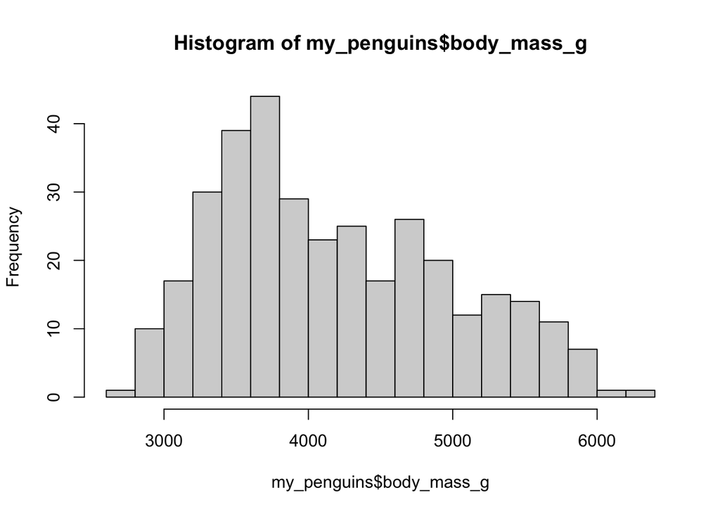

```r
my_penguins$mass_kg <- my_penguins$body_mass_g / 1000

hist(my_penguins$body_mass_g, breaks = 20)
```

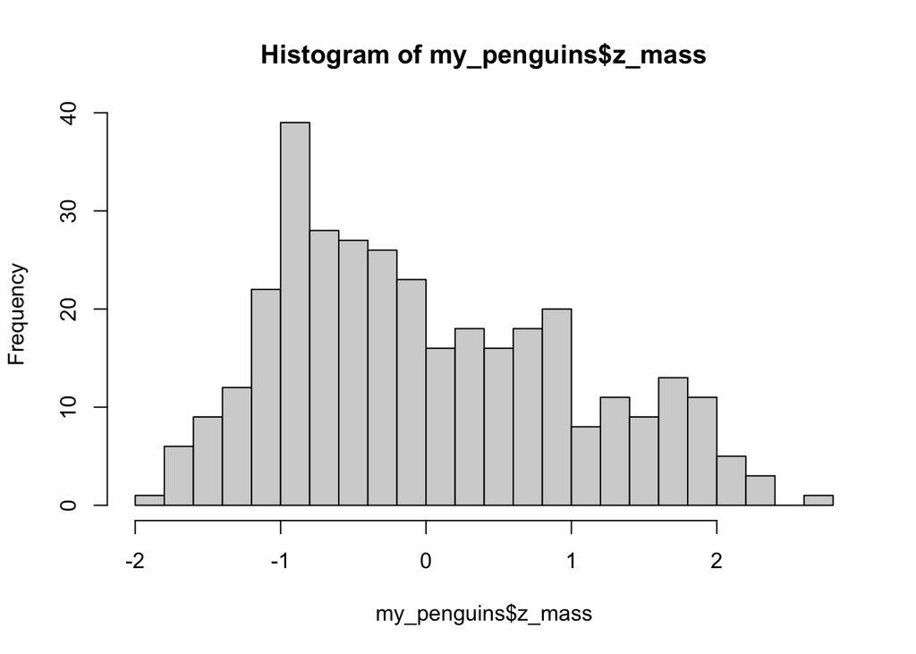

```r
my_penguins$z_mass <- as.numeric(scale(my_penguins$body_mass_g))
hist(my_penguins$z_mass, breaks = 20)
```

```r
my_penguins$mass_class <- cut(my_penguins$body_mass_g, breaks = 4)
```

## 3.16 Transforming penguins, with `dplyr`

```r
library("dplyr")
my_penguins$body_mass_g |> summary()
```

```
#>    Min. 1st Qu.  Median    Mean 3rd Qu.    Max.     NAs
#>    2700    3550    4050    4202    4750    6300       2
```

```r
my_penguins |>
  mutate(mc2 = case_when(
    body_mass_g < 3500 ~ "light",
    body_mass_g < 4500 ~ "medium",
    .default = "heavy")
  ) -> my_penguins

table(my_penguins$mc2)
```

```
#>
#>  heavy  light medium
#>    120     71    153
```

Notice here the “right hand assignment” & the order of the classes - what “should be done on top”?

## 3.17 Saving and exporting

We are done for the day, let’s save/export things - there are many ways to do so

```r
head(my_penguins)
```

```
#>   study_name sample_number                             species region    island
#> 1    PAL0708             1 Adelie Penguin (Pygoscelis adeliae) Anvers Torgersen
#> 2    PAL0708             2 Adelie Penguin (Pygoscelis adeliae) Anvers Torgersen
#> 3    PAL0708             3 Adelie Penguin (Pygoscelis adeliae) Anvers Torgersen
#> 4    PAL0708             4 Adelie Penguin (Pygoscelis adeliae) Anvers Torgersen
#> 5    PAL0708             5 Adelie Penguin (Pygoscelis adeliae) Anvers Torgersen
#> 6    PAL0708             6 Adelie Penguin (Pygoscelis adeliae) Anvers Torgersen
#>                stage individual_id clutch_completion   date_egg
#> 1 Adult, 1 Egg Stage          N1A1               Yes 2007-11-11
#> 2 Adult, 1 Egg Stage          N1A2               Yes 2007-11-11
#> 3 Adult, 1 Egg Stage          N2A1               Yes 2007-11-16
#> 4 Adult, 1 Egg Stage          N2A2               Yes 2007-11-16
#> 5 Adult, 1 Egg Stage          N3A1               Yes 2007-11-16
#> 6 Adult, 1 Egg Stage          N3A2               Yes 2007-11-16
#>   culmen_length_mm culmen_depth_mm flipper_length_mm body_mass_g    sex
#> 1             39.1            18.7               181        3750   MALE
#> 2             39.5            17.4               186        3800 FEMALE
#> 3             40.3            18.0               195        3250 FEMALE
#> 4               NA              NA                NA          NA   <NA>
#> 5             36.7            19.3               193        3450 FEMALE
#> 6             39.3            20.6               190        3650   MALE
#>   delta_15_n_o_oo delta_13_c_o_oo mass_kg     z_mass        mass_class    mc2
#> 1              NA              NA    3.75 -0.5633167 (3.6e+03,4.5e+03] medium
#> 2         8.94956       -24.69454    3.80 -0.5009690 (3.6e+03,4.5e+03] medium
#> 3         8.36821       -25.33302    3.25 -1.1867934 (2.7e+03,3.6e+03]  light
#> 4              NA              NA      NA         NA              <NA>  heavy
#> 5         8.76651       -25.32426    3.45 -0.9374027 (2.7e+03,3.6e+03]  light
#> 6         8.66496       -25.29805    3.65 -0.6880121 (3.6e+03,4.5e+03] medium
```

```r
dir.create("output")

save(my_penguins, file = "output/mypeng.RData")
saveRDS(my_penguins, file = "output/mypeng.RDS")

write.csv(my_penguins, file = "output/my_penguins.csv")
write.csv(my_penguins, file = "output/my_penguins_norownames.csv", row.names = FALSE)
readr::write_csv(my_penguins, file = "output/my_penguins_with_readr.csv")
write.table(my_penguins, file = "output/my_penguins.txt", sep = ";")

writexl::write_xlsx(my_penguins, path = "output/my_penguins.xlsx")

save.image(file = "output/my_session.RData")
```

CHECK - THOSE - OPTIONS (or get burned afterwards…)

## 3.18 Some extra challenges

- Take your first analytical decision: remove some data points, e.g. filter out the rows where we have no info on the sex
- Clean up the text values (species, for example)
- (harder) Make your `my_penguins` look like as similar as possible to the `penguins`
- (harder) This dataset is in the so-called wide format, and it has FOUR essential measurements - can you think of a way to make it in the long format? “How can this be useful”? (the `tidyr` package can be your friend!)
- Excel files can be a real mess - can you find one out in the wild and import that?

```
#> [1] 1376
#> [1] 1376
```

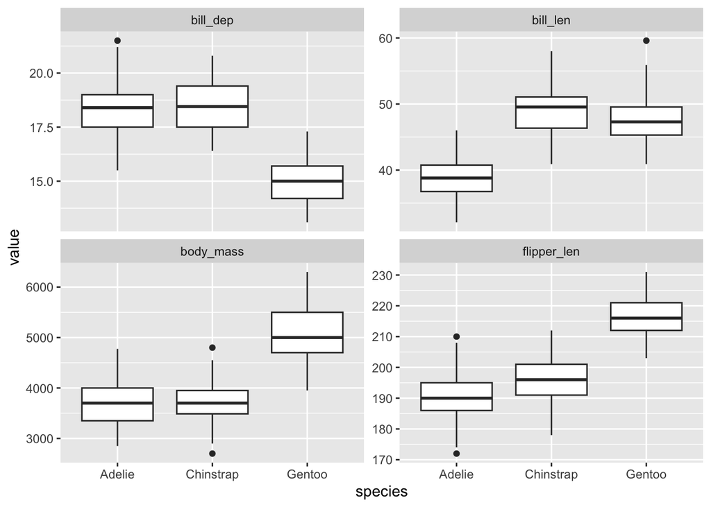

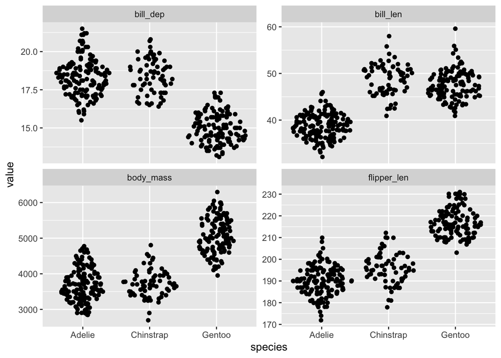

```
#>     species    island   n
#> 1    Adelie    Biscoe  44
#> 2    Adelie     Dream  56
#> 3    Adelie Torgersen  52
#> 4 Chinstrap     Dream  68
#> 5    Gentoo    Biscoe 124
#> # A tibble: 3 × 4
#>   species   Biscoe Dream Torgersen
#>   <fct>      <int> <int>     <int>
#> 1 Adelie        44    56        52
#> 2 Chinstrap      0    68         0
#> 3 Gentoo       124     0         0
#> [1] 344   7
```

# 4 Chapter 4

Here you can find the material for the topics addressed in Chapter 4

## 4.1 Required packages

We are going to need these packages

```r
library("dplyr")
library("janitor")
library("NHANES")
library("readxl")
library("writexl")
library("haven")
```

## 4.2 NHANES, in this course

- We will use the `NHANES` **package**: cycles **2009-10 and 2011-12**, about 10,000 rows, 77 variables, already cleaned
- We will retrieve some **CDC files** (SAS `.XPT`): one file per topic, with the cycle as a letter suffix (`_F` = 2009-10, `_G` = 2011-12)
- Same people, two sources: this is why we will **join** these together

## 4.3 Meet `dplyr`

`dplyr` is one of the main packages of the so called `tidyverse`

The functions in `dplyr` are also called verbs

Each verb does **one thing**, takes a data frame, and returns a data frame. That is why you can chain them together nicely with `|>`

Yes, most of the operations can very well be done with base-R, but this flavour is sometimes well rooted in how one thinks data analysis

## 4.4 The verbs of `dplyr`

- Acting on **Rows**
  - `filter()` - keep rows that meet a condition
  - `arrange()` - sort rows
  - `distinct()` - remove duplicate rows
- Acting on **Columns**
  - `select()` - keep, drop or reorder columns
  - `rename()` - change column names
  - `mutate()` - create or change columns
- Acting on **Groups**
  - `group_by()` + `summarise()` - one summary row per group
  - `count()` - shortcut: how many rows per group
- Acting on **Tables**
  - `left_join()` - add columns from another table
  - `bind_rows()` - stack tables on top of each other

## 4.5 An example of dplyr

```r
NHANES |>
  filter(Age >= 18) |>                       # rows
  mutate(obese = BMI >= 30) |>               # columns
  group_by(Sex) |>                           # groups
  summarise(prop_obese = mean(obese, na.rm = TRUE))
```

```
#> # A tibble: 2 × 2
#>   Sex    prop_obese
#>   <fct>       <dbl>
#> 1 female      0.355
#> 2 male        0.356
```

*Read it as a sentence: “take the data, **then** keep adults, **then** add a column, **then** …”*

Official dplyr (and more) cheat sheet: https://rstudio.github.io/cheatsheets/

## 4.6 Our guiding question

**What is the prevalence of diabetes by BMI category, and how does it compare with HbA1c?**

Let’s think out loud, what will we need?

Where can we check what we have in the `NHANES` data?

Do we have everything we need? Do we need to retrieve some additional data?

## 4.7 R object: the NHANES package

Load the package and the dataset itself, and have a first glance at that

```r
library("NHANES")
data(NHANES)
head(NHANES)
```

```
#>      ID SurveyYr    Sex SexOrientation Age AgeDecade AgeMonths Race1 Race3
#> 1 51624  2009_10   male   Heterosexual  34     30-39       409 White  <NA>
#> 2 51624  2009_10   male   Heterosexual  34     30-39       409 White  <NA>
#> 3 51624  2009_10   male   Heterosexual  34     30-39       409 White  <NA>
#> 4 51625  2009_10   male           <NA>   4       0-9        49 Other  <NA>
#> 5 51630  2009_10 female   Heterosexual  49     40-49       596 White  <NA>
#> 6 51638  2009_10   male           <NA>   9       0-9       115 White  <NA>
#>      Education MaritalStatus    HHIncome HHIncomeMid Poverty HomeRooms HomeOwn
#> 1  High School       Married 25000-34999       30000    1.36         6     Own
#> 2  High School       Married 25000-34999       30000    1.36         6     Own
#> 3  High School       Married 25000-34999       30000    1.36         6     Own
#> 4         <NA>          <NA> 20000-24999       22500    1.07         9     Own
#> 5 Some College   LivePartner 35000-44999       40000    1.91         5    Rent
#> 6         <NA>          <NA> 75000-99999       87500    1.84         6    Rent
#>         Work Weight Length HeadCirc Height   BMI BMICatUnder20yrs   BMI_WHO
```

[output cut: 62 more lines]

```r
glimpse(NHANES)
```

```
#> Rows: 10,000
#> Columns: 77
#> $ ID               <int> 51624, 51624, 51624, 51625, 51630, 51638, 51646, 5164…
#> $ SurveyYr         <fct> 2009_10, 2009_10, 2009_10, 2009_10, 2009_10, 2009_10,…
#> $ Sex              <fct> male, male, male, male, female, male, male, female, f…
#> $ SexOrientation   <fct> Heterosexual, Heterosexual, Heterosexual, NA, Heteros…
#> $ Age              <int> 34, 34, 34, 4, 49, 9, 8, 45, 45, 45, 66, 58, 54, 10, …
#> $ AgeDecade        <fct>  30-39,  30-39,  30-39,  0-9,  40-49,  0-9,  0-9,  40…
#> $ AgeMonths        <int> 409, 409, 409, 49, 596, 115, 101, 541, 541, 541, 795,…
#> $ Race1            <fct> White, White, White, Other, White, White, White, Whit…
#> $ Race3            <fct> NA, NA, NA, NA, NA, NA, NA, NA, NA, NA, NA, NA, NA, N…
#> $ Education        <fct> High School, High School, High School, NA, Some Colle…
#> $ MaritalStatus    <fct> Married, Married, Married, NA, LivePartner, NA, NA, M…
#> $ HHIncome         <fct> 25000-34999, 25000-34999, 25000-34999, 20000-24999, 3…
#> $ HHIncomeMid      <int> 30000, 30000, 30000, 22500, 40000, 87500, 60000, 8750…
```

[output cut: 64 more lines]

## 4.8 Which variables would you pick?

Which few variables would you pick to describe a population (always remember the purpose we had!)

```r
nh <- NHANES |>
  select(ID, SurveyYr, Gender, Age, BMI, Diabetes, BPSys1, BPDia1, Smoke100)
```

(Yes, we took a few more, but this is ok)

## 4.9 Let’s take a round trip - with Excel

Exporting & reimporting… What can possibly go wrong there

```r
write_xlsx(nh, "datasets/nhanes_small.xlsx")
file.exists("datasets/nhanes_small.xlsx")
```

```
#> [1] TRUE
```

```r
nh_xl <- read_excel("datasets/nhanes_small.xlsx")
identical(nh, nh_xl)
```

```
#> [1] FALSE
```

```r
# all.equal(nh, nh_xl)
glimpse(nh)
```

```
#> Rows: 10,000
#> Columns: 9
#> $ ID       <int> 51624, 51624, 51624, 51625, 51630, 51638, 51646, 51647, 51647…
#> $ SurveyYr <fct> 2009_10, 2009_10, 2009_10, 2009_10, 2009_10, 2009_10, 2009_10…
#> $ Gender   <fct> male, male, male, male, female, male, male, female, female, f…
#> $ Age      <int> 34, 34, 34, 4, 49, 9, 8, 45, 45, 45, 66, 58, 54, 10, 58, 50, …
#> $ BMI      <dbl> 32.22, 32.22, 32.22, 15.30, 30.57, 16.82, 20.64, 27.24, 27.24…
#> $ Diabetes <fct> No, No, No, No, No, No, No, No, No, No, No, No, No, No, No, N…
#> $ BPSys1   <int> 114, 114, 114, NA, 118, 84, 114, 106, 106, 106, 124, 108, 136…
#> $ BPDia1   <int> 88, 88, 88, NA, 82, 50, 46, 62, 62, 62, 64, 76, 86, 66, NA, 6…
#> $ Smoke100 <fct> Yes, Yes, Yes, NA, Yes, NA, NA, No, No, No, Yes, No, No, NA, …
```

```r
glimpse(nh_xl)
```

```
#> Rows: 10,000
#> Columns: 9
#> $ ID       <dbl> 51624, 51624, 51624, 51625, 51630, 51638, 51646, 51647, 51647…
#> $ SurveyYr <chr> "2009_10", "2009_10", "2009_10", "2009_10", "2009_10", "2009_…
#> $ Gender   <chr> "male", "male", "male", "male", "female", "male", "male", "fe…
#> $ Age      <dbl> 34, 34, 34, 4, 49, 9, 8, 45, 45, 45, 66, 58, 54, 10, 58, 50, …
#> $ BMI      <dbl> 32.22, 32.22, 32.22, 15.30, 30.57, 16.82, 20.64, 27.24, 27.24…
#> $ Diabetes <chr> "No", "No", "No", "No", "No", "No", "No", "No", "No", "No", "…
#> $ BPSys1   <dbl> 114, 114, 114, NA, 118, 84, 114, 106, 106, 106, 124, 108, 136…
#> $ BPDia1   <dbl> 88, 88, 88, NA, 82, 50, 46, 62, 62, 62, 64, 76, 86, 66, NA, 6…
#> $ Smoke100 <chr> "Yes", "Yes", "Yes", NA, "Yes", NA, NA, "No", "No", "No", "Ye…
```

## 4.10 A quick assessment

Using these functions will never kill a kitten

```r
dim(nh)
```

```
#> [1] 10000     9
```

```r
summary(nh)
```

```
#>        ID           SurveyYr       Gender          Age             BMI
#>  Min.   :51624   2009_10:5000   female:5020   Min.   : 0.00   Min.   :12.88
#>  1st Qu.:56904   2011_12:5000   male  :4980   1st Qu.:17.00   1st Qu.:21.58
#>  Median :62160                                Median :36.00   Median :25.98
#>  Mean   :61945                                Mean   :36.74   Mean   :26.66
#>  3rd Qu.:67039                                3rd Qu.:54.00   3rd Qu.:30.89
#>  Max.   :71915                                Max.   :80.00   Max.   :81.25
#>                                                               NAs    :366
#>  Diabetes       BPSys1          BPDia1       Smoke100
#>  No :9098   Min.   : 72.0   Min.   :  0.00   No :4024
#>  Yes: 760   1st Qu.:106.0   1st Qu.: 62.00   Yes:3211
#>  NAs: 142   Median :116.0   Median : 70.00   NAs:2765
#>             Mean   :119.1   Mean   : 68.28
#>             3rd Qu.:128.0   3rd Qu.: 76.00
#>             Max.   :232.0   Max.   :118.00
#>             NAs    :1763    NAs    :1763
```

```r
colSums(is.na(nh))
```

```
#>       ID SurveyYr   Gender      Age      BMI Diabetes   BPSys1   BPDia1
#>        0        0        0        0      366      142     1763     1763
#> Smoke100
#>     2765
```

```r
nh |> summarise(across(everything(), n_distinct))
```

```
#>     ID SurveyYr Gender Age  BMI Diabetes BPSys1 BPDia1 Smoke100
#> 1 6779        2      2  81 2074        3     71     52        3
```

Don’t be afraid to put extra check on your data, even if it seems not too useful

## 4.11 Subsetting data - Selecting variables

Can you guess what these commands will return?

```r
nh |> select(Age, BMI)
```

```
#>       Age   BMI
#> 1      34 32.22
#> 2      34 32.22
#> 3      34 32.22
#> 4       4 15.30
#> 5      49 30.57
#> 6       9 16.82
#> 7       8 20.64
#> 8      45 27.24
#> 9      45 27.24
```

```r
<snipped 9991 lines>
nh |> select(-SurveyYr)
```

```
#>          ID Gender Age   BMI Diabetes BPSys1 BPDia1 Smoke100
#> 1     51624   male  34 32.22       No    114     88      Yes
#> 2     51624   male  34 32.22       No    114     88      Yes
#> 3     51624   male  34 32.22       No    114     88      Yes
#> 4     51625   male   4 15.30       No     NA     NA     <NA>
#> 5     51630 female  49 30.57       No    118     82      Yes
#> 6     51638   male   9 16.82       No     84     50     <NA>
#> 7     51646   male   8 20.64       No    114     46     <NA>
#> 8     51647 female  45 27.24       No    106     62       No
#> 9     51647 female  45 27.24       No    106     62       No
```

```r
<snipped 9991 lines>
nh |> select(starts_with("BP"))
```

```
#>       BPSys1 BPDia1
#> 1        114     88
#> 2        114     88
#> 3        114     88
#> 4         NA     NA
#> 5        118     82
#> 6         84     50
#> 7        114     46
#> 8        106     62
#> 9        106     62
```

```r
<snipped 9991 lines>
```

## 4.12 Subsetting data - Selecting cases & performing logical comparisons

What are these commands returning?

```r
nh |> filter(Age >= 18)
```

```
#>         ID SurveyYr Gender Age   BMI Diabetes BPSys1 BPDia1 Smoke100
#> 1    51624  2009_10   male  34 32.22       No    114     88      Yes
#> 2    51624  2009_10   male  34 32.22       No    114     88      Yes
#> 3    51624  2009_10   male  34 32.22       No    114     88      Yes
#> 4    51630  2009_10 female  49 30.57       No    118     82      Yes
#> 5    51647  2009_10 female  45 27.24       No    106     62       No
#> 6    51647  2009_10 female  45 27.24       No    106     62       No
#> 7    51647  2009_10 female  45 27.24       No    106     62       No
#> 8    51654  2009_10   male  66 23.67       No    124     64      Yes
#> 9    51656  2009_10   male  58 23.69       No    108     76       No
```

```r
<snipped 7472 lines>
nh |> filter(Age >= 18, Gender == "female")
```

```
#>         ID SurveyYr Gender Age   BMI Diabetes BPSys1 BPDia1 Smoke100
#> 1    51630  2009_10 female  49 30.57       No    118     82      Yes
#> 2    51647  2009_10 female  45 27.24       No    106     62       No
#> 3    51647  2009_10 female  45 27.24       No    106     62       No
#> 4    51647  2009_10 female  45 27.24       No    106     62       No
#> 5    51666  2009_10 female  58 26.22       No     NA     NA      Yes
#> 6    51685  2009_10 female  56 19.73       No     94     74       No
#> 7    51685  2009_10 female  56 19.73       No     94     74       No
#> 8    51691  2009_10 female  57 20.66       No    122     82      Yes
#> 9    51707  2009_10 female  64 27.18      Yes    138     72       No
```

```r
<snipped 3786 lines>
nh |> filter(Smoke100 == "Yes" | Diabetes == "Yes")
```

```
#>         ID SurveyYr Gender Age   BMI Diabetes BPSys1 BPDia1 Smoke100
#> 1    51624  2009_10   male  34 32.22       No    114     88      Yes
#> 2    51624  2009_10   male  34 32.22       No    114     88      Yes
#> 3    51624  2009_10   male  34 32.22       No    114     88      Yes
#> 4    51630  2009_10 female  49 30.57       No    118     82      Yes
#> 5    51654  2009_10   male  66 23.67       No    124     64      Yes
#> 6    51666  2009_10 female  58 26.22       No     NA     NA      Yes
#> 7    51677  2009_10   male  33 28.54       No    126     80      Yes
#> 8    51678  2009_10   male  60 25.84       No    154     98      Yes
#> 9    51691  2009_10 female  57 20.66       No    122     82      Yes
```

```r
<snipped 3589 lines>
nh |> filter(SurveyYr %in% c("2009_10", "2011_12"))
```

```
#>          ID SurveyYr Gender Age   BMI Diabetes BPSys1 BPDia1 Smoke100
#> 1     51624  2009_10   male  34 32.22       No    114     88      Yes
#> 2     51624  2009_10   male  34 32.22       No    114     88      Yes
#> 3     51624  2009_10   male  34 32.22       No    114     88      Yes
#> 4     51625  2009_10   male   4 15.30       No     NA     NA     <NA>
#> 5     51630  2009_10 female  49 30.57       No    118     82      Yes
#> 6     51638  2009_10   male   9 16.82       No     84     50     <NA>
#> 7     51646  2009_10   male   8 20.64       No    114     46     <NA>
#> 8     51647  2009_10 female  45 27.24       No    106     62       No
#> 9     51647  2009_10 female  45 27.24       No    106     62       No
```

```r
<snipped 9991 lines>
```

## 4.13 Predict first: how many rows?

```r
nrow(nh)
```

```
#> [1] 10000
```

```r
nrow(filter(nh, BMI > 30))
```

```
#> [1] 2751
```

```r
nrow(filter(nh, BMI <= 30))
```

```
#> [1] 6883
```

```r
nrow(filter(nh, BMI > 30)) + nrow(filter(nh, BMI <= 30))   # vs nrow(nh)?
```

```
#> [1] 9634
```

What is the missing piece?

```r
sum(is.na(nh$BMI))    # the missing piece
```

```
#> [1] 366
```

## 4.14 Handling duplicates

Is `ID` unique?

Nope

```r
head(nh)
```

```
#>      ID SurveyYr Gender Age   BMI Diabetes BPSys1 BPDia1 Smoke100
#> 1 51624  2009_10   male  34 32.22       No    114     88      Yes
#> 2 51624  2009_10   male  34 32.22       No    114     88      Yes
#> 3 51624  2009_10   male  34 32.22       No    114     88      Yes
#> 4 51625  2009_10   male   4 15.30       No     NA     NA     <NA>
#> 5 51630  2009_10 female  49 30.57       No    118     82      Yes
#> 6 51638  2009_10   male   9 16.82       No     84     50     <NA>
```

```r
nrow(nh)
```

```
#> [1] 10000
```

```r
n_distinct(nh$ID)
```

```
#> [1] 6779
```

```r
nh |> count(ID) |> filter(n > 1)
```

```
#>         ID n
#> 1    51624 3
#> 2    51647 3
#> 3    51685 2
#> 4    51692 2
#> 5    51702 2
#> 6    51711 2
#> 7    51718 2
#> 8    51720 2
#> 9    51722 4
```

```r
<snipped 2124 lines>
nh |> get_dupes(ID)
```

```
#>         ID dupe_count SurveyYr Gender Age   BMI Diabetes BPSys1 BPDia1 Smoke100
#> 1    70324          8  2011_12 female  14 23.30      Yes    100     78     <NA>
#> 2    70324          8  2011_12 female  14 23.30      Yes    100     78     <NA>
#> 3    70324          8  2011_12 female  14 23.30      Yes    100     78     <NA>
#> 4    70324          8  2011_12 female  14 23.30      Yes    100     78     <NA>
#> 5    70324          8  2011_12 female  14 23.30      Yes    100     78     <NA>
#> 6    70324          8  2011_12 female  14 23.30      Yes    100     78     <NA>
#> 7    70324          8  2011_12 female  14 23.30      Yes    100     78     <NA>
#> 8    70324          8  2011_12 female  14 23.30      Yes    100     78     <NA>
#> 9    62927          7  2011_12   male  63 30.80       No    132     74       No
```

```r
<snipped 5345 lines>
```

## 4.15 Remove duplicates

There’s many ways to do so, here’s one

```r
nh_u <- nh |>
  distinct(ID, .keep_all = TRUE)   # will keep first row per ID
nrow(nh_u)
```

```
#> [1] 6779
```

```r
nh |>
  distinct() |>                    # fully identical rows only
  nrow()
```

```
#> [1] 6779
```

## 4.16 Sorting data - Sorting cases

Again - what happens here?

```r
nh_u |> arrange(Age)
```

```
#>         ID SurveyYr Gender Age   BMI Diabetes BPSys1 BPDia1 Smoke100
#> 1    51962  2009_10 female   0    NA     <NA>     NA     NA     <NA>
#> 2    52066  2009_10 female   0    NA     <NA>     NA     NA     <NA>
#> 3    52300  2009_10   male   0    NA     <NA>     NA     NA     <NA>
#> 4    52373  2009_10   male   0    NA     <NA>     NA     NA     <NA>
#> 5    52435  2009_10 female   0    NA     <NA>     NA     NA     <NA>
#> 6    52442  2009_10 female   0    NA     <NA>     NA     NA     <NA>
#> 7    52459  2009_10 female   0    NA     <NA>     NA     NA     <NA>
#> 8    52461  2009_10 female   0    NA     <NA>     NA     NA     <NA>
#> 9    52792  2009_10   male   0    NA     <NA>     NA     NA     <NA>
```

```r
<snipped 6770 lines>
nh_u |> arrange(desc(BMI))
```

```
#>         ID SurveyYr Gender Age   BMI Diabetes BPSys1 BPDia1 Smoke100
#> 1    52315  2009_10 female  52 81.25      Yes     NA     NA       No
#> 2    70466  2011_12 female  25 80.60       No    130     80       No
#> 3    69207  2011_12 female  30 69.00       No    110     62       No
#> 4    61693  2009_10 female  33 68.63      Yes    118     84       No
#> 5    59688  2009_10 female  39 67.83      Yes    124     74      Yes
#> 6    55580  2009_10 female  60 66.96       No    140     70       No
#> 7    58817  2009_10 female  45 65.62       No     NA     NA       No
#> 8    54461  2009_10 female  72 65.19      Yes    156     74       No
#> 9    59522  2009_10   male  37 63.91      Yes    106     72      Yes
```

```r
<snipped 6770 lines>
nh_u |> arrange(Gender, desc(Age))
```

```
#>         ID SurveyYr Gender Age   BMI Diabetes BPSys1 BPDia1 Smoke100
#> 1    51790  2009_10 female  80 27.25       No    170     90       No
#> 2    52067  2009_10 female  80 33.11       No    120     62       No
#> 3    52255  2009_10 female  80 24.75       No    134     48       No
#> 4    52343  2009_10 female  80 25.76       No    140     80       No
#> 5    52453  2009_10 female  80 26.52       No    128     62      Yes
#> 6    52674  2009_10 female  80 24.94       No    144     74       No
#> 7    52774  2009_10 female  80 30.81       No    106     56      Yes
#> 8    52841  2009_10 female  80 31.37       No    156     42       No
#> 9    52856  2009_10 female  80 30.01       No    138     58       No
```

```r
<snipped 6770 lines>
```

## 4.17 Sorting data - Sorting variables

… and here?

```r
nh_u |> relocate(BMI, .after = Age)
```

```
#>         ID SurveyYr Gender Age   BMI Diabetes BPSys1 BPDia1 Smoke100
#> 1    51624  2009_10   male  34 32.22       No    114     88      Yes
#> 2    51625  2009_10   male   4 15.30       No     NA     NA     <NA>
#> 3    51630  2009_10 female  49 30.57       No    118     82      Yes
#> 4    51638  2009_10   male   9 16.82       No     84     50     <NA>
#> 5    51646  2009_10   male   8 20.64       No    114     46     <NA>
#> 6    51647  2009_10 female  45 27.24       No    106     62       No
#> 7    51654  2009_10   male  66 23.67       No    124     64      Yes
#> 8    51656  2009_10   male  58 23.69       No    108     76       No
#> 9    51657  2009_10   male  54 26.03       No    136     86       No
```

```r
<snipped 6770 lines>
nh_u |> select(Age, everything())
```

```
#>      Age    ID SurveyYr Gender   BMI Diabetes BPSys1 BPDia1 Smoke100
#> 1     34 51624  2009_10   male 32.22       No    114     88      Yes
#> 2      4 51625  2009_10   male 15.30       No     NA     NA     <NA>
#> 3     49 51630  2009_10 female 30.57       No    118     82      Yes
#> 4      9 51638  2009_10   male 16.82       No     84     50     <NA>
#> 5      8 51646  2009_10   male 20.64       No    114     46     <NA>
#> 6     45 51647  2009_10 female 27.24       No    106     62       No
#> 7     66 51654  2009_10   male 23.67       No    124     64      Yes
#> 8     58 51656  2009_10   male 23.69       No    108     76       No
#> 9     54 51657  2009_10   male 26.03       No    136     86       No
```

```r
<snipped 6770 lines>
```

Much of this is quite intuitive, but the verbs and functions make it pretty straightforward to work with data…

## 4.18 Transforming data - Renaming variables

Sometimes it is for comfort, some other for readability…

```r
nh_u <- nh_u |> rename(sex = Gender, survey_year = SurveyYr)
```

## 4.19 Transforming data - Recoding variables & categorizing

Mixing the flavours we have seen already for the `penguins`…

```r
nh_u <- nh_u |>
  mutate(
    bmi_class = case_when(
      BMI < 18.5 ~ "underweight",
      BMI < 25   ~ "normal",
      BMI < 30   ~ "overweight",
      BMI >= 30  ~ "obese"
    ),
    age_group = cut(Age, breaks = c(0, 18, 40, 60, Inf), right = FALSE)
  )

count(nh_u, bmi_class)
```

```
#>     bmi_class    n
#> 1      normal 1944
#> 2       obese 1799
#> 3  overweight 1777
#> 4 underweight  955
#> 5        <NA>  304
```

```r
count(nh_u, age_group)
```

```
#>   age_group    n
#> 1    [0,18) 1944
#> 2   [18,40) 1956
#> 3   [40,60) 1613
#> 4  [60,Inf) 1266
```

## 4.20 Transforming data - Calculate new variables from old

One can do pretty much everything

Meaningful things come first, let’s put it like this - can we get for example the mean arterial pressure? How is that computed?

```r
nh_u <- nh_u |>
  mutate(map_bp = BPDia1 + (BPSys1 - BPDia1) / 3)   # mean arterial pressure

summary(nh_u$map_bp)
```

```
#>    Min. 1st Qu.  Median    Mean 3rd Qu.    Max.     NAs
#>   27.33   76.67   84.67   84.72   92.67  140.00    1352
```

## 4.21 Group-by operations

One step at a time, we are getting close!

```r
nh_u |>
  count(bmi_class)
```

```
#>     bmi_class    n
#> 1      normal 1944
#> 2       obese 1799
#> 3  overweight 1777
#> 4 underweight  955
#> 5        <NA>  304
```

```r
nh_u |>
  count(bmi_class) |>
  mutate(prop = n / sum(n))
```

```
#>     bmi_class    n       prop
#> 1      normal 1944 0.28676796
#> 2       obese 1799 0.26537837
#> 3  overweight 1777 0.26213306
#> 4 underweight  955 0.14087624
#> 5        <NA>  304 0.04484437
```

## 4.22 Let’s go back to the basics

Just briefly

```r
# nh_u$Diabetes == "Yes"

sum(nh_u$Diabetes == "Yes")
```

```
#> [1] NA
```

```r
sum(nh_u$Diabetes == "Yes", na.rm = TRUE)
```

```
#> [1] 552
```

```r
sum(is.na(nh_u$Diabetes))
```

```
#> [1] 126
```

```r
nrow(nh_u)
```

```
#> [1] 6779
```

```r
552/(6779-126)
```

```
#> [1] 0.08297009
```

```r
# or use this
mean(nh_u$Diabetes == "Yes", na.rm = TRUE)
```

```
#> [1] 0.08297009
```

## 4.23 Wait a second!

We have all we need to answer our guiding question!

```r
nh_u |>
  group_by(bmi_class) |>
  summarise(
    n = n(),
    diabetes = mean(Diabetes == "Yes", na.rm = TRUE)
  )
```

```
#> # A tibble: 5 × 3
#>   bmi_class       n diabetes
#>   <chr>       <int>    <dbl>
#> 1 normal       1944  0.0391
#> 2 obese        1799  0.171
#> 3 overweight   1777  0.0889
#> 4 underweight   955  0.00209
#> 5 <NA>          304  0.0444
```

```r
# what happens without na.rm = TRUE ?
nh_u |>
  group_by(bmi_class) |>
  summarise(
    n = n(),
    diabetes = mean(Diabetes == "Yes"))
```

```
#> # A tibble: 5 × 3
#>   bmi_class       n diabetes
#>   <chr>       <int>    <dbl>
#> 1 normal       1944 NA
#> 2 obese        1799 NA
#> 3 overweight   1777  0.0889
#> 4 underweight   955  0.00209
#> 5 <NA>          304 NA
```

## 4.24 Stepping up the challenge

What if we have two grouping variables?

Let’s do this by `age_group` AND `bmi_class`!

```r
nh_u |>
  group_by(age_group, bmi_class) |>
  summarise(
    n = n(),
    diabetes = mean(Diabetes == "Yes", na.rm = TRUE)
  )
```

```
#> # A tibble: 20 × 4
#> # Groups:   age_group [4]
#>    age_group bmi_class       n diabetes
#>    <fct>     <chr>       <int>    <dbl>
#>  1 [0,18)    normal        551  0.00545
#>  2 [0,18)    obese         103  0.0291
#>  3 [0,18)    overweight    169  0.00592
#>  4 [0,18)    underweight   866  0
#>  5 [0,18)    <NA>          255  0
#>  6 [18,40)   normal        693  0.0115
#>  7 [18,40)   obese         632  0.0411
#>  8 [18,40)   overweight    566  0.0159
#>  9 [18,40)   underweight    52  0
#> 10 [18,40)   <NA>           13  0
#> 11 [40,60)   normal        393  0.0560
#> 12 [40,60)   obese         592  0.193
#> 13 [40,60)   overweight    592  0.0828
#> 14 [40,60)   underweight    22  0
#> 15 [40,60)   <NA>           14  0.0714
#> 16 [60,Inf)  normal        307  0.140
#> 17 [60,Inf)  obese         472  0.350
#> 18 [60,Inf)  overweight    450  0.22
#> 19 [60,Inf)  underweight    15  0.133
#> 20 [60,Inf)  <NA>           22  0.318
```

## 4.25 Combining data sets

Getting data from the NHANES website

We need data from https://wwwn.cdc.gov/Nchs/Nhanes/ - for both time points!

Go to https://wwwn.cdc.gov/Nchs/Nhanes/continuousnhanes/default.aspx?BeginYear=2009

-> Laboratory Data -> Search for Glycohemoglobin -> Copy the link to that

```r
# check the URLs on the CDC site before class: they have moved in the past

url_f <- "https://wwwn.cdc.gov/Nchs/Data/Nhanes/Public/2009/DataFiles/GHB_F.xpt"
download.file(url_f, destfile = "datasets/GHB_F.XPT")

url_g <- "https://wwwn.cdc.gov/Nchs/Data/Nhanes/Public/2011/DataFiles/GHB_G.XPT"
download.file(url_g, destfile = "datasets/GHB_G.XPT")
```

## 4.26 Reading SAS transport files

Yep, just like that

```r
ghb_f <- haven::read_xpt("datasets/GHB_F.XPT")    # 2009-10
ghb_g <- haven::read_xpt("datasets/GHB_G.XPT")    # 2011-12

glimpse(ghb_g)
```

```
#> Rows: 6,549
#> Columns: 2
#> $ SEQN  <dbl> 62161, 62163, 62164, 62165, 62169, 62170, 62171, 62172, 62174, 6…
#> $ LBXGH <dbl> 5.1, 5.5, 4.9, 5.9, 5.4, 5.2, 5.0, 5.6, 5.0, 5.4, 5.8, 5.7, 5.7,…
```

```r
glimpse(ghb_f)
```

```
#> Rows: 7,369
#> Columns: 2
#> $ SEQN  <dbl> 51624, 51626, 51628, 51629, 51630, 51633, 51635, 51640, 51641, 5…
#> $ LBXGH <dbl> 5.2, 5.7, 6.0, 5.1, 5.3, 5.4, 6.8, 5.1, 5.6, 11.0, 5.7, 5.1, 5.9…
```

## 4.27 Adding more rows

Combining together the two datasets from the different periods

```r
dim(ghb_f)
```

```
#> [1] 7369    2
```

```r
dim(ghb_g)
```

```
#> [1] 6549    2
```

```r
ghb <- bind_rows(ghb_f, ghb_g)
dim(ghb) # does the arithmetic work?
```

```
#> [1] 13918     2
```

```r
n_distinct(ghb$SEQN)
```

```
#> [1] 13918
```

Of course, some obligatory checks are expected BEFORE doing this

## 4.28 Adding more columns: join!

We want to keep all observation in our `nh_u`

```r
nrow(nh_u)
```

```
#> [1] 6779
```

```r
nh_ghb <- nh_u |>
  left_join(ghb, by = join_by(ID == SEQN))

nrow(nh_ghb) # Is this the same as before? always check!
```

```
#> [1] 6779
```

We could have also used an `inner_join()` (keeps observations from x that have a matching key in y)

## 4.29 Who did not match?

Can be just out of curiosity…

```r
nh_u |>
  anti_join(ghb, by = join_by(ID == SEQN)) |> nrow()
```

```
#> [1] 1308
```

```r
ghb |>
  anti_join(nh_u, by = join_by(SEQN == ID)) |> nrow()
```

```
#> [1] 8447
```

```r
nh_ghb |>
  summarise(missing_hba1c = sum(is.na(LBXGH)))
```

```
#>   missing_hba1c
#> 1          1604
```

```r
# equivalent to...
nh_ghb$LBXGH |> is.na() |> sum()
```

```
#> [1] 1604
```

Can you spot what is different?

## 4.30 Do the HbA1c value make sense?

Here comes the other half of the guiding question!

```r
nh_ghb |>
  group_by(Diabetes) |>
  summarise(n = n(), mean_hba1c = mean(LBXGH, na.rm = TRUE))
```

```
#> # A tibble: 3 × 3
#>   Diabetes     n mean_hba1c
#>   <fct>    <int>      <dbl>
#> 1 No        6101       5.44
#> 2 Yes        552       7.11
#> 3 <NA>       126       7.1
```

Can you tell me in **one sentence** what you have found with your results?

## 4.31 Joining is powerful

But sometimes it can bite you (one-to-many)

```r
patients <- tibble(id = 1:3, name = c("A", "B", "C"))
visits   <- tibble(id = c(1, 1, 2), date = c("2024-01-05", "2024-02-10", "2024-01-20"))

left_join(patients, visits, by = "id")   # 3 patients in, 4 rows out
```

```
#> # A tibble: 4 × 3
#>      id name  date
#>   <dbl> <chr> <chr>
#> 1     1 A     2024-01-05
#> 2     1 A     2024-02-10
#> 3     2 B     2024-01-20
#> 4     3 C     <NA>
```

## 4.32 Saving data - as R objects and as plain text

This goes pretty straightforward

```r
saveRDS(nh_ghb, "datasets/nhanes_ghb.RDS")
readr::write_csv(nh_ghb, "datasets/nhanes_ghb.csv")

# Excel was already done in part 1
list.files("datasets")
```

```
#> [1] "beatles.xlsx"              "dirty_penguins.RDS"
#> [3] "GHB_F.XPT"                 "GHB_G.XPT"
#> [5] "nhanes_but_as_Robject.RDS" "nhanes_ghb.csv"
#> [7] "nhanes_ghb.RDS"            "nhanes_small.xlsx"
```

Side note: You might notice that sometimes I do not type the arguments of a functions.

There is NEVER harm in typing them extra (the positional arguments sometimes can give you unexpected behaviors)

```r
nh_ghb |>
  group_by(Diabetes) |>
  summarise(n = n(), mean_hba1c = mean(LBXGH, na.rm = TRUE))
```

```
#> # A tibble: 3 × 3
#>   Diabetes     n mean_hba1c
#>   <fct>    <int>      <dbl>
#> 1 No        6101       5.44
#> 2 Yes        552       7.11
#> 3 <NA>       126       7.1
```

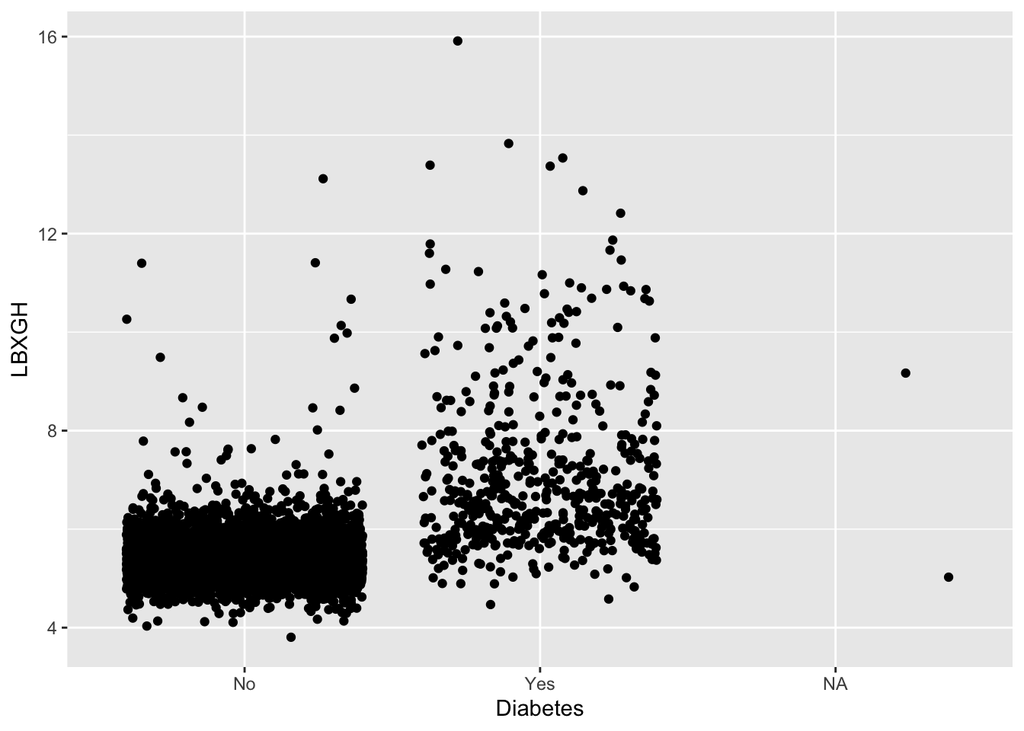

```r
library("ggplot2")
ggplot(nh_ghb,
       aes(x = Diabetes, y = LBXGH)) + geom_jitter()
```

Do you see what I see?

## 4.33 Some extra challenges

- Answer the same question, but restrict to only one time window
- Take another guiding question
  - Is sleep related to BMI?
  - Does physical activity go with a lower diabetes prevalence?
  - Is smoking related to blood pressure, by age group?
- Grab the health insurance status information (HIQ)
  - Is health insurance related to income and age?
- Come up with your own new question and address that!

For each of these cases, write **one sentence** under your result that states what you found.

# 5 Chapter 5

Here you can find the material for the topics addressed in Chapter 5

## 5.1 There are data types

Some of them, we already encountered - and some of them are… a bit special

- Numbers
- Strings
- Factors
- Dates
- Missing (yep, a missing info can also be/become an information)

We have been working with our `nh_ghb` dataset, let’s reload it into our session

```r
library("NHANES")
library("dplyr")

# checkpoint from chapter 4
nh_ghb <- readRDS("datasets/nhanes_ghb.RDS")
```

## 5.2 Factors - text vs. categories

Let’s have a closer look, with a specific focus on this!

```r
class(nh_ghb$bmi_class)
```

```
#> [1] "character"
```

```r
unique(nh_ghb$bmi_class)
```

```
#> [1] "obese"       "underweight" "normal"      "overweight"  NA
```

```r
class(nh_ghb$Diabetes)
```

```
#> [1] "factor"
```

```r
levels(nh_ghb$Diabetes)
```

```
#> [1] "No"  "Yes"
```

```r
unclass(nh_ghb$Diabetes)
```

```
#>    [1]  1  1  1  1  1  1  1  1  1  1  1  1  1  1  1  1  1  1  1  1  1  1  2  2
#>   [25]  1  2  1  1  1  1  1  1  1  1  1  1  1  1  1  2  2  1  1  1  1  1  1  1
#>   [49]  1  1  1  1  1  1  1  1  1  1  1  1  1  1  1  1  1  1  1  1  1  2  2  1
#>   [73]  1  1  2  1  1  1  1  1  2  1  2  1  1  1  1  1  1  1  1  1  1  1  1  1
#>   [97]  1  1  1  1  1  1  2  1  1  1  1  1  1 NA  1  1  1  1  1  1  1  1  1  1
#>  [121]  1  1  1  1  1  1  1  1  1  1  1  1  1  1  1  2  1  1  1  1  1  1  1  1
#>  [145]  2  1  1 NA  1  1  1  1  1  2  1  1  1  1  1  1  1  1  1  1  1  1  1  1
#>  [169]  1  1  1  1  1  1  1  2  1  1  1  1  1  1  2  1  1  1  2  1  1  1  1  1
#>  [193]  1  1  2  1  1  1  1  1  1  1  2  1  1  1  1  1  1  1  1  1  1  1  1  1
#>  [217]  2  1  1  1  1  1  1  1  1  1  1  1  1  1  1  1  1  1  1  1  1  1  1 NA
#>  [241]  1  1  1  1  2  1  1  1  1  1  2  1  1  1  1  1  1  1  1  1  1  2  1  1
#>  [265]  2  1  1  1 NA  1  1  1  1  1  1  1  1  1  2  2  1  1  1  1  1 NA NA  2
#>  [289]  1  2  1  1  1  1  1 NA  1 NA  1  1  1  1  1  1  1  1  1  1  2  1  1  1
#>  [313]  1  1  1  1  1  1  1  1  1  1  1  1  1  1  1  1  1  1  1  1  1  1  1  1
#>  [337]  1  1  1  2  2  1  1  1  2  1  1  1  1  2  2  1  1  1  1  1  1  1  1  1
```

[output cut: 270 more lines]

```r
table(nh_ghb$bmi_class)
```

```
#>
#>      normal       obese  overweight underweight
#>        1944        1799        1777         955
```

```r
table(nh_ghb$bmi_class, useNA = "always")
```

```
#>
#>      normal       obese  overweight underweight        <NA>
#>        1944        1799        1777         955         304
```

What order is this? is it meaningful?

## 5.3 Levels have an order

… and it can be related to a meaning

```r
levels(NHANES$Education)
```

```
#> [1] "8th Grade"      "9 - 11th Grade" "High School"    "Some College"
#> [5] "College Grad"
```

```r
levels(NHANES$AgeDecade)       # Can you spot anything odd in the labels?
```

```
#> [1] " 0-9"   " 10-19" " 20-29" " 30-39" " 40-49" " 50-59" " 60-69" " 70+"
```

```r
table(NHANES$Education)
```

```
#>
#>      8th Grade 9 - 11th Grade    High School   Some College   College Grad
#>            451            888           1517           2267           2098
```

```r
## or
NHANES |>
  count(Education)
```

```
#>        Education    n
#> 1      8th Grade  451
#> 2 9 - 11th Grade  888
#> 3    High School 1517
#> 4   Some College 2267
#> 5   College Grad 2098
#> 6           <NA> 2779
```

The “information content” is the same, the behavior/format sometimes is not. Where do you find all this info on functions?

## 5.4 Set the order yourself

Let’s fix the `bmi_class`

```r
nh_ghb <- nh_ghb |>
  mutate(
    bmi_class = factor(bmi_class,
                       levels = c("underweight", "normal", "overweight", "obese"))
  )

levels(nh_ghb$bmi_class)
```

```
#> [1] "underweight" "normal"      "overweight"  "obese"
```

```r
count(nh_ghb, bmi_class)           # now the table reads in a meaningful order
```

```
#>     bmi_class    n
#> 1 underweight  955
#> 2      normal 1944
#> 3  overweight 1777
#> 4       obese 1799
#> 5        <NA>  304
```

What happened to our `NA`s?

For more factor-centric functions, you can have a look at the `forcats` package (yes, this is an intentional anagram of `factors`).

## 5.5 Why bother?

Well, because the order shows up also in plots

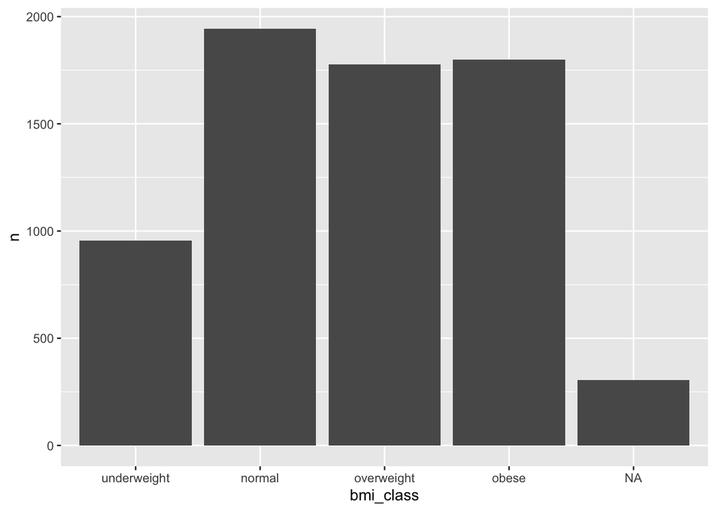

```r
library("ggplot2")

nh_ghb |>
  # drop_na(bmi_class) |>
  count(bmi_class) |>
  ggplot(aes(x = bmi_class, y = n)) +
  geom_col()
```

## 5.6 Missing values - `NA` is “unknown”

It is not zero!

Back to some basics:

```r
x <- c(120, 135, NA, 110)
mean(x)
```

```
#> [1] NA
```

```r
mean(x, na.rm = TRUE)
```

```
#> [1] 121.6667
```

```r
is.na(x)
```

```
#> [1] FALSE FALSE  TRUE FALSE
```

```r
sum(is.na(x))
```

```
#> [1] 1
```

## 5.7 How much is missing, and where?

This is quite a useful overview (kind of applies to any rectangular data…)

```r
nh_ghb |>
  summarise(across(everything(), ~ sum(is.na(.x)))) |>
  t()
```

```
#>             [,1]
#> ID             0
#> survey_year    0
#> sex            0
#> Age            0
#> BMI          304
#> Diabetes     126
#> BPSys1      1352
#> BPDia1      1352
#> Smoke100    2125
#> bmi_class    304
#> age_group      0
#> map_bp      1352
#> LBXGH       1604
```

## 5.8 Back to blood pressure

How many/much is missing?

```r
sum(is.na(nh_ghb$BPSys1))
```

```
#> [1] 1352
```

```r
mean(is.na(nh_ghb$BPSys1))         # proportion missing
```

```
#> [1] 0.1994394
```

*Who is missing? Make a guess before you look.*

## 5.9 Is it random?

Let’s have a look

```r
nh_ghb |>
  mutate(bp_missing = is.na(BPSys1)) |>
  group_by(age_group) |>
  summarise(n = n(), prop_missing = mean(bp_missing))
```

```
#> # A tibble: 4 × 3
#>   age_group     n prop_missing
#>   <fct>     <int>        <dbl>
#> 1 [0,18)     1944       0.499
#> 2 [18,40)    1956       0.0808
#> 3 [40,60)    1613       0.0794
#> 4 [60,Inf)   1266       0.0758
```

In this case, the info is missing by **design** (children not measured), not by accident.

You can check it with `range(nh_ghb$Age[!is.na(nh_ghb$BPSys1)])`.

## 5.10 Three ways to deal with NAs

Run these commands sequentially, and see what comes out

```r
# 1. ignore inside the function
nh_ghb |>
  summarise(mean_sbp = mean(BPSys1, na.rm = TRUE),
            n = n())
```

```
#>   mean_sbp    n
#> 1 118.9663 6779
```

```r
# 2. drop rows with NA in one variable
nh_ghb |>
  drop_na(BPSys1) |>
  summarise(mean_sbp = mean(BPSys1),
            n = n())
```

```
#>   mean_sbp    n
#> 1 118.9663 5427
```

```r
# 3. filter explicitly
nh_ghb |>
  filter(!is.na(BPSys1)) |>
  summarise(mean_sbp = mean(BPSys1),
            n = n())
```

```
#>   mean_sbp    n
#> 1 118.9663 5427
```

`drop_na()` without column names drops rows with **any** NA.

Check `nrow()` before and after. Which one is the right choice is an explicit **analytic decision**, not just a technicality!

## 5.11 Does it matter for the answer?

This is a rhetorical question…

```r
# all ages vs. adults only
nh_ghb |>
  summarise(mean_sbp = mean(BPSys1, na.rm = TRUE))
```

```
#>   mean_sbp
#> 1 118.9663
```

```r
## vs
nh_ghb |>
  filter(Age >= 18) |>
  summarise(mean_sbp = mean(BPSys1, na.rm = TRUE))
```

```
#>   mean_sbp
#> 1 122.0355
```

Among adults, is `BPSys1` missing more often in one sex or one age group? Or one BMI class? Use `is.na()` inside `group_by() |> summarise()`.

## 5.12 Dates

This is how they can come in

```r
linelist <- data.frame(
  id     = 1:6,
  onset  = c("2024-03-01", "2024-03-02", "2024-03-05",
             "2024-03-09", "2024-03-10", "2024-03-12"),
  report = c("2024-03-04", "2024-03-05", "2024-03-07",
             "2024-03-12", "2024-03-15", "2024-03-14")
)

glimpse(linelist)
```

```
#> Rows: 6
#> Columns: 3
#> $ id     <int> 1, 2, 3, 4, 5, 6
#> $ onset  <chr> "2024-03-01", "2024-03-02", "2024-03-05", "2024-03-09", "2024-0…
#> $ report <chr> "2024-03-04", "2024-03-05", "2024-03-07", "2024-03-12", "2024-0…
```

R does not know these are dates (yet) - Your best friend, possibly: `lubridate` (yes, package developers often like word puns)

## 5.13 Parse these dates!

This is - of course - just an appetizer

```r
library("lubridate")
linelist <- linelist |>
  mutate(onset = ymd(onset),
         report = ymd(report))

glimpse(linelist)
```

```
#> Rows: 6
#> Columns: 3
#> $ id     <int> 1, 2, 3, 4, 5, 6
#> $ onset  <date> 2024-03-01, 2024-03-02, 2024-03-05, 2024-03-09, 2024-03-10, 202…
#> $ report <date> 2024-03-04, 2024-03-05, 2024-03-07, 2024-03-12, 2024-03-15, 20…
```

```r
dmy("01/03/2024")              # other orders: dmy(), mdy()
```

```
#> [1] "2024-03-01"
```

```r
ymd("2024-13-45")              # what happens with impossible dates?
```

```
#> [1] NA
```

## 5.14 Compute with dates

Keeping it simple here…

```r
linelist |>
  mutate(delay = report - onset)               # a time difference
```

```
#>   id      onset     report  delay
#> 1  1 2024-03-01 2024-03-04 3 days
#> 2  2 2024-03-02 2024-03-05 3 days
#> 3  3 2024-03-05 2024-03-07 2 days
#> 4  4 2024-03-09 2024-03-12 3 days
#> 5  5 2024-03-10 2024-03-15 5 days
#> 6  6 2024-03-12 2024-03-14 2 days
```

```r
linelist |>
  mutate(delay_days = as.numeric(report - onset)) |>
  summarise(mean_delay = mean(delay_days))
```

```
#>   mean_delay
#> 1          3
```

… but you can see that some simple functions make this quite easy!

## 5.15 From dates to weeks

There are clever ways of converting among units!

```r
linelist |>
  mutate(week = floor_date(onset, unit = "week"))
```

```
#>   id      onset     report       week
#> 1  1 2024-03-01 2024-03-04 2024-02-25
#> 2  2 2024-03-02 2024-03-05 2024-02-25
#> 3  3 2024-03-05 2024-03-07 2024-03-03
#> 4  4 2024-03-09 2024-03-12 2024-03-03
#> 5  5 2024-03-10 2024-03-15 2024-03-10
#> 6  6 2024-03-12 2024-03-14 2024-03-10
```

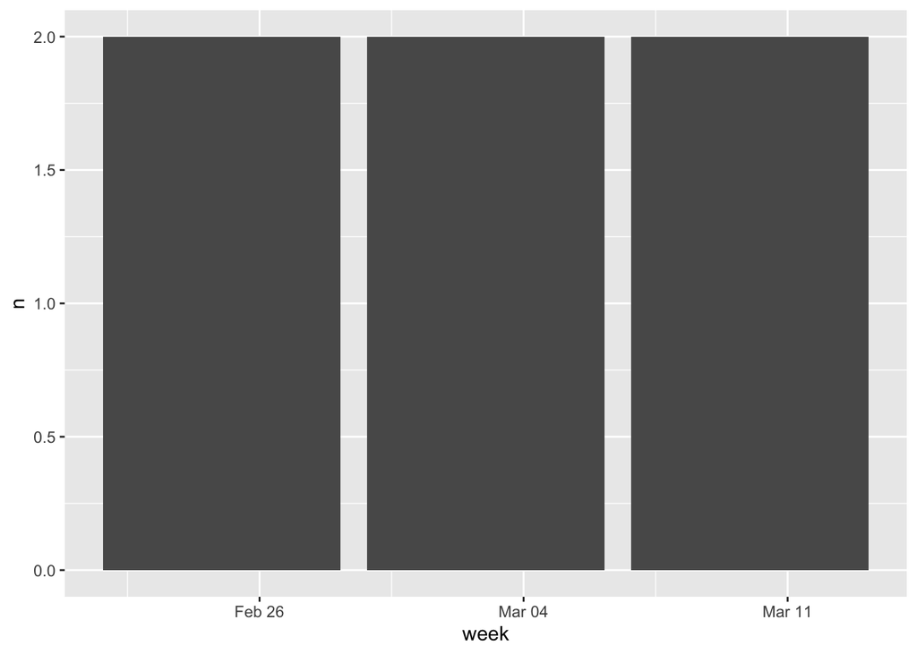

```r
linelist |>
  mutate(week = floor_date(onset, unit = "week")) |>
  count(week) |>
  ggplot(aes(x = week, y = n)) +
  geom_col()
```

NHANES has no calendar dates, but outbreak data will be full of them.

## 5.16 Develop (at least) these habits

- Check the **type** of every column (`glimpse()` or `summary()` can be your very good friends)
- Set the **order** of categories on purpose
- Ask **why** something is missing before dealing with it

Always remember: to get the right answer, start asking the right question(s) - and don’t be afraid to ask questions.

# 6 Chapter 6

Here you can find the material for the topics addressed in Chapter 6

## 6.1 Let’s get all set for this chapter!

```r
library("dplyr")
library("tidyr")
library("gapminder")
library("ggplot2")

# checkpoint from chapter 4, with the factor order from chapter 5
nh <- readRDS("datasets/nhanes_ghb.RDS") |>
  mutate(bmi_class = factor(bmi_class,
                            levels = c("underweight", "normal", "overweight", "obese")))
```

## 6.2 ggplot basics - The grammar: a plot is built from layers

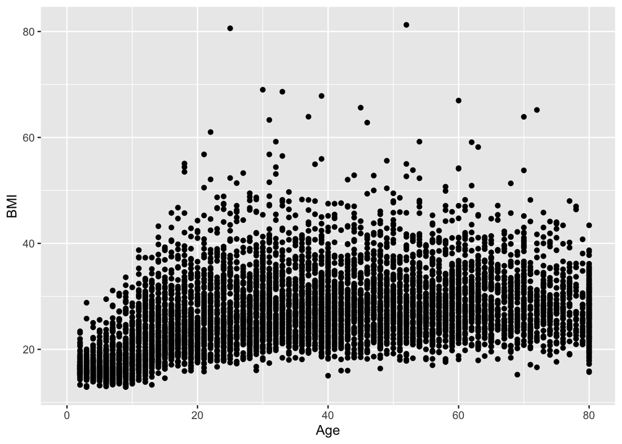

```r
ggplot(data = nh, mapping = aes(x = Age, y = BMI)) +
  geom_point()
```

- **data**: which table
- **aes()**: which columns go where (x, y, colour, size, …)
- **geom_…()**: how to draw them (points, bars, boxes, …)
- layers are added with `+`

Something inside `aes()` will be mapped to the data, outside of it will be treated as a constant